# Lab3_BlueTeam

Blue Team

1/30/2019

### Question

Does smoking affect the weight loss as one gets older? What’s the difference of weight loss between male and female?

### Signifigance

This question is signifigant becuase if there is an adverse side effect on smokers and weight loss. Than smokers will most likely become even less healthy as they age which can effect how companies may want to provide health plans.

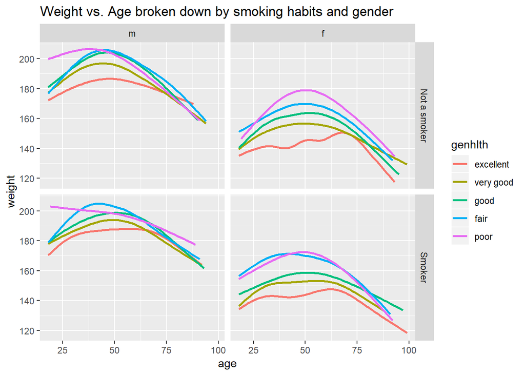

```r
# Team Plot
ggplot(data = cdc, mapping = aes( x = age, y = weight, color = genhlth)) +
geom_smooth(se = FALSE) +
facet_grid(smoke100~gender) +
  ggtitle('Weight vs. Age broken down by smoking habits and gender')
```

### Recomendation

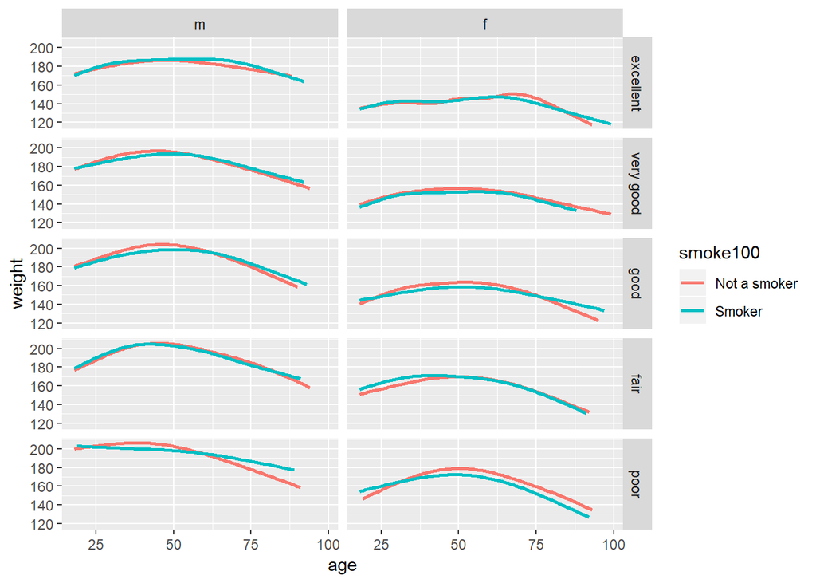

```r
# Plot 1
ggplot(data = cdc, mapping = aes( x = age, y = weight, color = smoke100)) +
geom_smooth(se = FALSE) +
facet_grid(genhlth~gender)
```

We can see here that age vs. weight is different for male and female. It is also different for different levels of general health. However, it is nearly exactly the same for smokers vs. non smokers.

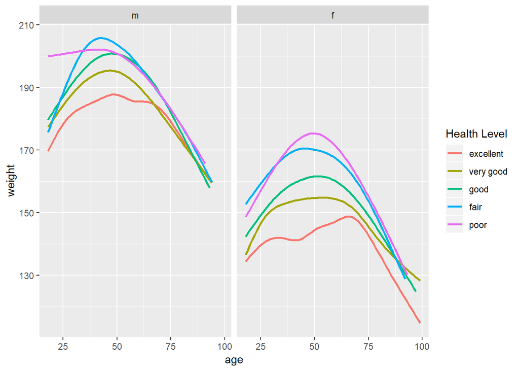

```r
# Plot 2
ggplot(data = cdc, mapping = aes( x = age, y = weight, color = genhlth)) +
geom_smooth(se=FALSE) +
  facet_wrap(~gender) +
   scale_color_discrete(name = 'Health Level')
```

We can see here that different health levels age differently with respect to weight. We can also see how men begin to decrease in weight sooner than women do.

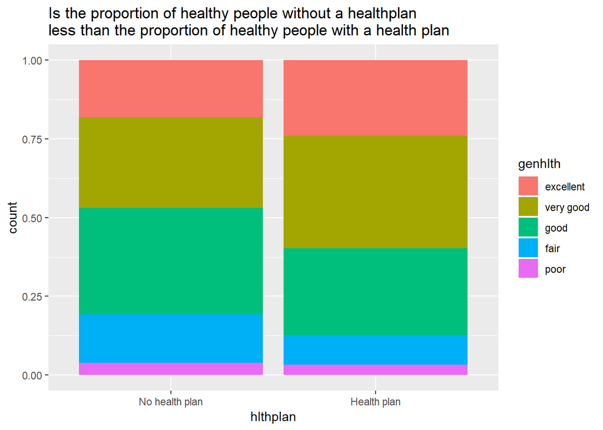

```r
# Plot 3
ggplot(data = cdc) +
geom_bar(mapping = aes(x = hlthplan, fill =genhlth ), position = "fill")+
ggtitle("Is the proportion of healthy people without a healthplan
less than the proportion of healthy people with a health plan")
```

I Brandon Bowen, created a bar graph with the “fill” option in order to clearly lable the general health of people. Then I used the position = fill function to better compare the two sides since the count is vastly different for the two bar charts. Based of the graph the two upper classes of general health has a higher porportion of people with health insurance, While the lower three classes of general health has a higher proportion with people without health insurance.

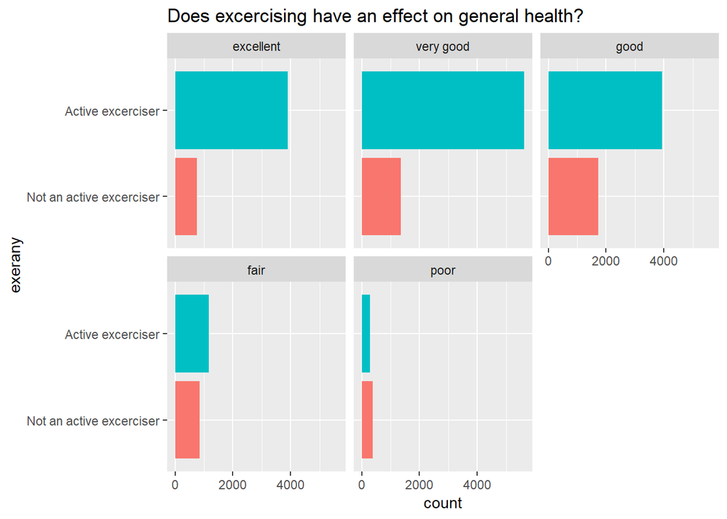

```r
# Plot 4
ggplot(data=cdc) +
  stat_count(mapping=aes(x=exerany, fill=exerany)) +
  facet_wrap(~genhlth) +
  coord_flip() +
  guides(fill=FALSE) +
  ggtitle("Does excercising have an effect on general health?")
```

Clearly, excercising had a positive effect on general health. The vast majority of the people in “excelent”, “very good”, and “good” general health are active excercisers.

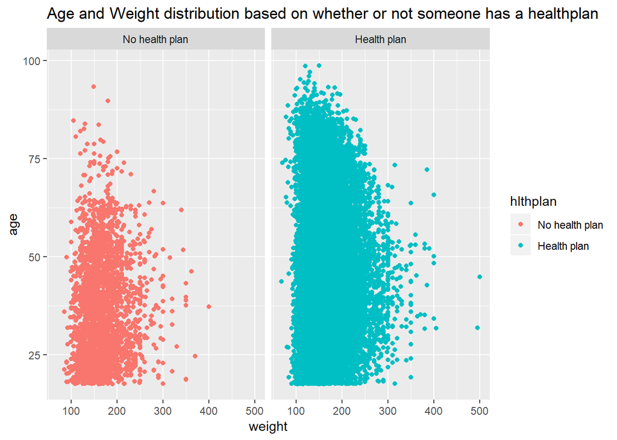

```r
# Plot 5
ggplot(data = cdc) +
  geom_jitter(data = cdc, mapping = aes(x = weight, y = age, color = hlthplan)) +
  facet_wrap(~ hlthplan) +
  ggtitle("Age and Weight distribution based on whether or not someone has a healthplan")
```

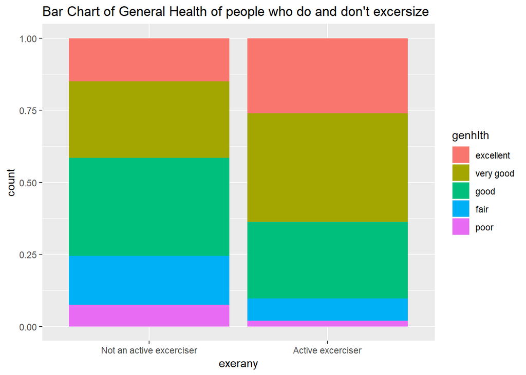

```r
# Plot 6
ggplot(data=cdc) +
geom_bar(mapping=aes(x = exerany, fill = genhlth), position = "fill") + labs(title = "Bar Chart of General Health of people who do and don't excersize")
```

This bar chart shows the proportion of people’s general health based on if they exersize or not. As we can see the percentage of people that have excellent health that do exersize is much greater than the percentage of people with excellent health if they do not exersize.

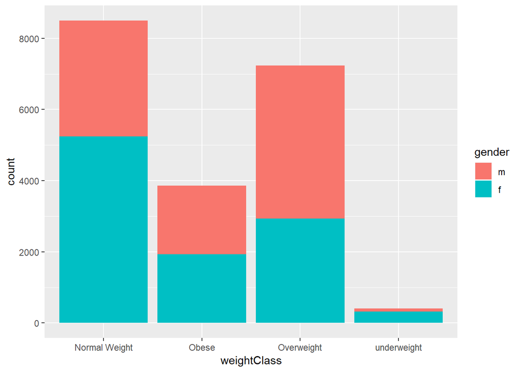

```r
# Plot 7
ggplot(data=mutate(cdc,
       bmi = weight/height^2 * 703,
       weightClass = ifelse(bmi < 18.5, "underweight",
                     ifelse(bmi < 25, "Normal Weight",
                     ifelse(bmi <= 30, "Overweight", "Obese")))))+
  geom_bar(mapping=aes(x=weightClass,fill=gender))
```

This is a histogram that displays the respondent’s weightClass, ranging from underweight to obese based on their BMI (Body Mass Index)

## Who Did What

- Matt worked on Team plot and plot 1, 2, and 3
- Brandon worked on Team plot and plot 3
- Nick worked on plot Team plot and plot 7
- Ryan worked on plot Team plot and plot 5
- Bing worked on plot on Team plot and plot 6

# Lab3_BlueTeam

Blue Team

1/30/2019

### Signifigance

This question is signifigant becuase if there is an adverse side effect on smokers and weight loss. Than smokers will most likely become even less healthy as they age which can effect how companies may want to provide health plans.

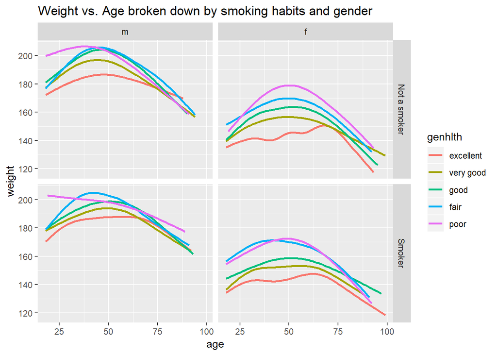

```r
# Team Plot
ggplot(data = cdc, mapping = aes( x = age, y = weight, color = genhlth)) +
geom_smooth(se = FALSE) +
facet_grid(smoke100~gender) +
  ggtitle('Weight vs. Age broken down by smoking habits and gender')
```

### Recomendation

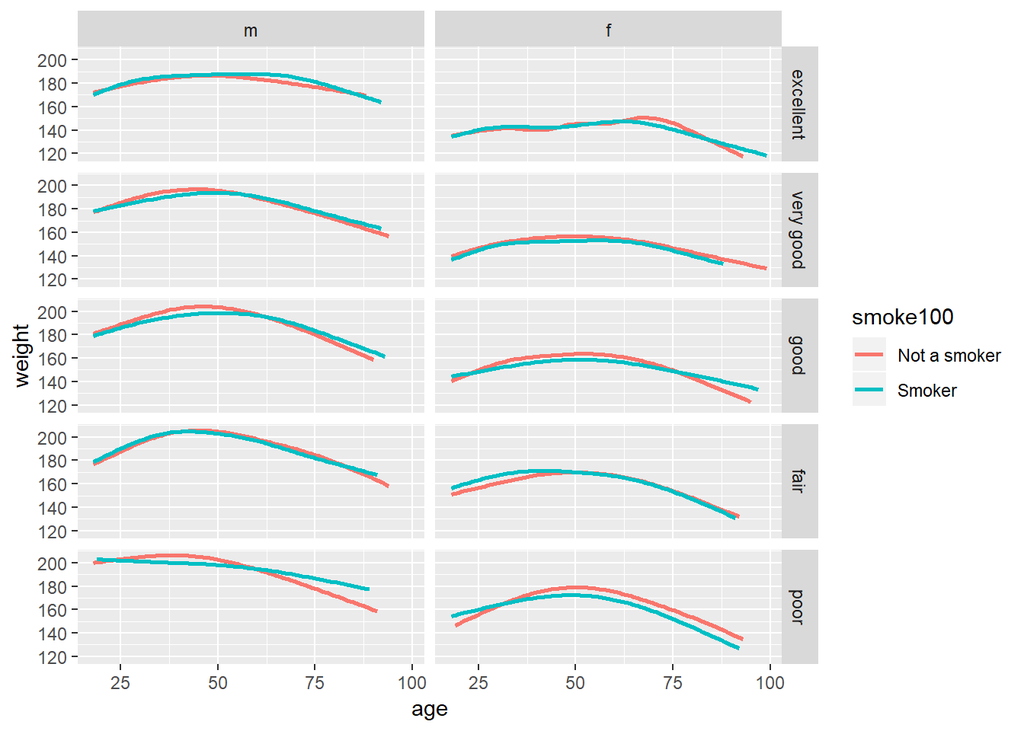

```r
# Plot 1
ggplot(data = cdc, mapping = aes( x = age, y = weight, color = smoke100)) +
geom_smooth(se = FALSE) +
facet_grid(genhlth~gender)
```

We can see here that age vs. weight is different for male and female. It is also different for different levels of general health. However, it is nearly exactly the same for smokers vs. non smokers.

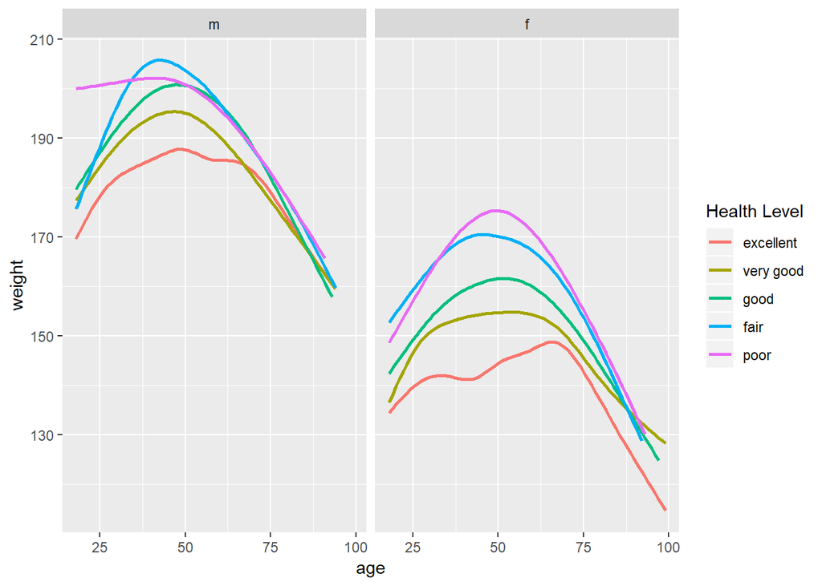

```r
# Plot 2
ggplot(data = cdc, mapping = aes( x = age, y = weight, color = genhlth)) +
geom_smooth(se=FALSE) +
  facet_wrap(~gender) +
   scale_color_discrete(name = 'Health Level')
```

We can see here that different health levels age differently with respect to weight. We can also see how men begin to decrease in weight sooner than women do.

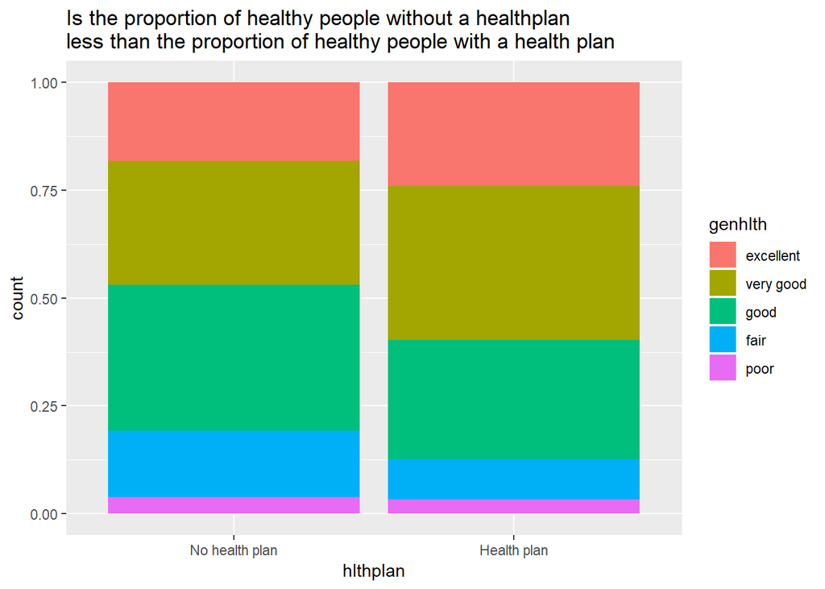

```r
# Plot 3
ggplot(data = cdc) +
geom_bar(mapping = aes(x = hlthplan, fill =genhlth ), position = "fill")+
ggtitle("Is the proportion of healthy people without a healthplan
less than the proportion of healthy people with a health plan")
```

I Brandon Bowen, created a bar graph with the “fill” option in order to clearly lable the general health of people. Then I used the position = fill function to better compare the two sides since the count is vastly different for the two bar charts. Based of the graph the two upper classes of general health has a higher porportion of people with health insurance, While the lower three classes of general health has a higher proportion with people without health insurance.

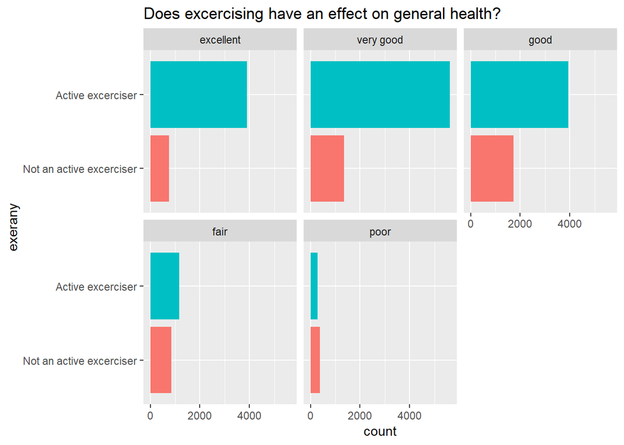

```r
# Plot 4
ggplot(data=cdc) +
  stat_count(mapping=aes(x=exerany, fill=exerany)) +
  facet_wrap(~genhlth) +
  coord_flip() +
  guides(fill=FALSE) +
  ggtitle("Does excercising have an effect on general health?")
```

Clearly, excercising had a positive effect on general health. The vast majority of the people in “excelent”, “very good”, and “good” general health are active excercisers.

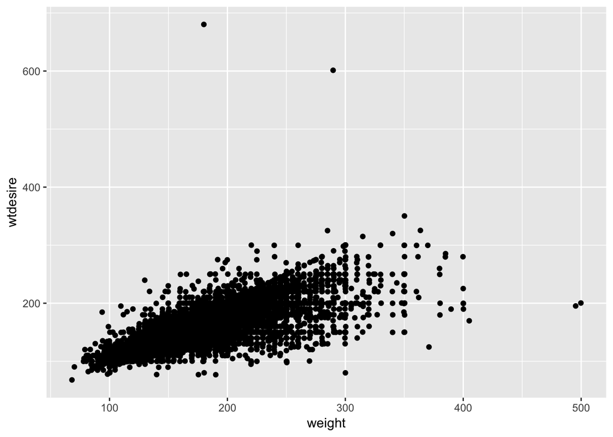

```r
# Plot 5
ggplot(data=cdc) +
  geom_jitter(aes(x=weight, y=wtdesire))
```

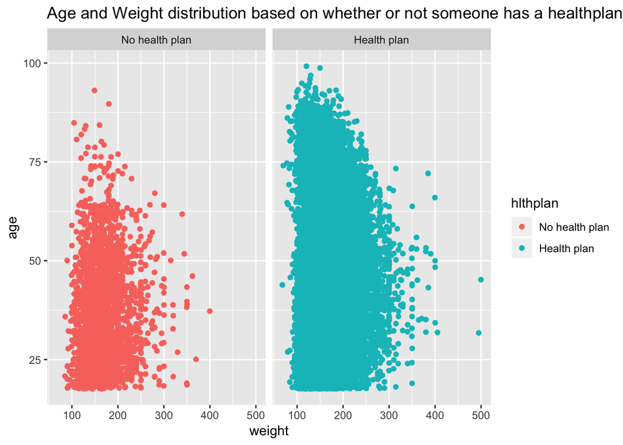

```r
# Plot 6
ggplot(data = cdc) +
  geom_jitter(data = cdc, mapping = aes(x = weight, y = age, color = hlthplan)) +
  facet_wrap(~ hlthplan) +
  ggtitle("Age and Weight distribution based on whether or not someone has a healthplan")
```

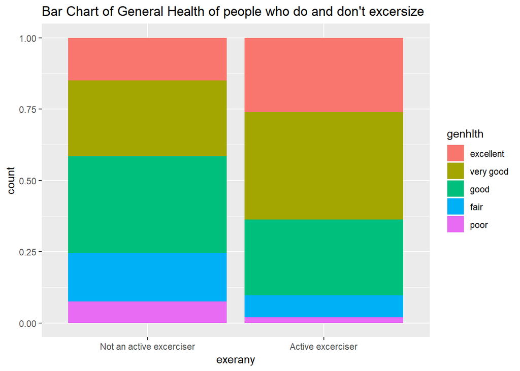

```r
# Plot 7
ggplot(data=cdc) +
geom_bar(mapping=aes(x = exerany, fill = genhlth), position = "fill") + labs(title = "Bar Chart of General Health of people who do and don't excersize")
```

This bar chart shows the proportion of people’s general health based on if they exersize or not. As we can see the percentage of people that have excellent health that do exersize is much greater than the percentage of people with excellent health if they do not exersize.

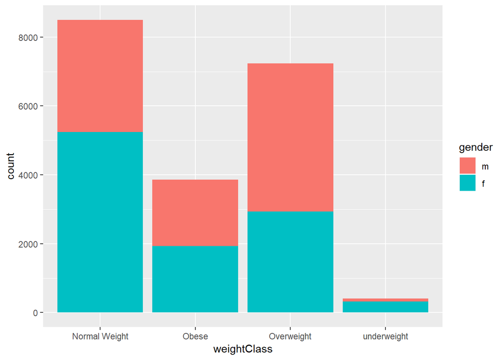

```r
# Plot 7
ggplot(data=mutate(cdc,
       bmi = weight/height^2 * 703,
       weightClass = ifelse(bmi < 18.5, "underweight",
                     ifelse(bmi < 25, "Normal Weight",
                     ifelse(bmi <= 30, "Overweight", "Obese")))))+
  geom_bar(mapping=aes(x=weightClass,fill=gender))
```

This is a histogram that displays the respondent’s weightClass, ranging from underweight to obese based on their BMI (Body Mass Index)